# Data Science Capstone Next Word Predictor (Shiny App)

15/09/2019

## Overview

This presentation is the **supporting documentation** for a **Shiny Application For Next Word Prediction** developed for the final project of the **Coursera Data Science Capstone**.

- **Introduction to the application**
- **Application Name:** Next Word Predictor
- **Based on:** Shiny framework + JavaScript codes + files containing American English texts from the set of corpora provided by HC Corpora (SwiftKey)
- **Required R Packages:** shiny, tm, stringr, ngrams
- **Purpose of the application**
- With this interactive application users will be able to input an english phrase (multiple words) in a text box input and the App will outputs a prediction of the next word. Users can continue writing or mouse-clicking on one of the predicted word to use it on the phrase.
- There is an extra option to adjust how many next words you want to predict.

## The prediction algorithm - Part I

To build an accurate and performative algorithm for this Shiny App, 4 steps were followed:

- **Download, explore, clean and partition the datasets**  
  -After exploring the files, the cleanup actions taken converted the data to plain text and lowercase.  
  -Profanities, numbers, punctuations and special characters have been removed.  
  -Data was then partitioned into one training set (70%) and one test set (30%) from the original data set.
- **Tokenizing the training data**  
  -Text prediction systems use n-grams to predict the next word based on the likelihood of its occurrence in the language’s n-grams.  
  -Unigrams, 2-grams, 3-grams, 4-grams and 5-grams were generated from the training data with the help of the *ngram* library.  
  -Considering the size of the data set and the processing limitations for the Shiny App, sampling the data was a *sine qua non* condition for pre-comparing and executing the prediction algorithm.  
  -Three dataset sample size cenarios were tested (2%, 5% and 10% of the original dataset size).

## The prediction algorithm - Part II

- **N-grams**  
  -The basic n-gram model took n-grams from one to four words to predict the next word.  
  -The first task was to generating n-grams and frequencies of the sampled training set.  
  -The n-gram tables have been customized to have three columns: **Col1** with the n-grams [**Predictor**], **Col2** with with the n-grams conditional probabilities and **Col3** with the final word of th n-gram [**Predicted Word**].
- **Model, prediction and accuracy**  
  -After testing three sample size (2%, 5% and 10% of the original dataset size) and for each size 1-grams to 5-grams the decision was to take a 5% sampling with 1-grams, 2-grams, 3-grams and 4-grams.  
  -Larger samples resulted in larger n-grams and did not work properly on this Shiny application.  
  -The performance measures used were perplexity and the accuracies of the first, second, and third predicted next words.  
  -The 5-grams was discarted because it resulted in a small gain in prediction but high impact on performance.

## Application print screen and link

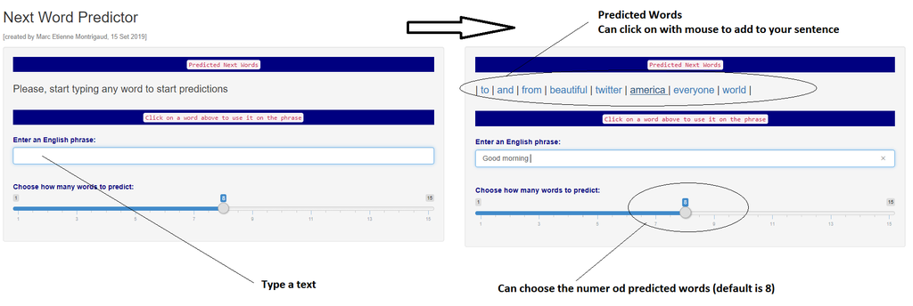

- **Apllication Deployed at** https://marcetienne.shinyapps.io/CourseraDtScCapstone/